# Entrega de problemas: Regresión.

Carmen Bonilla Urturi

26/11/2021

## Ejercicio 1

**Los datos del fichero Datos-geyser.txt corresponden al día de la observación (primera columna), el tiempo medido en minutos (segunda columna Y ) y el tiempo hasta la siguiente erupción (tercera columna X) del geyser *Old Faithful* en el parque norteamericano de Yellowstone.**

**(a) Representa gráficamente los datos, junto con el estimador de Nadaraya-Watson de la función de regresión de Y sobre X.**

En primer lugar leemos el fichero Datos-geyser.txt.

```r
datos.geyser <- read.csv("C:/Users/usuario/Desktop/MAE/Entrega3/Datos-geyser.txt", sep="")
```

Representamos gráficamente los datos donde el eje y corresponde al tiempo transcurrido hasta la primera erupción(Y), el eje x el tiempo transcurrido hasta la segunda erupción (X) y el día de la observación viene indicado mediante una escala de color. Para el estimador de Nadaraya-Watson empleamos el comando `geom_smooth()` con el método suavizado `loess`, tenemos en cuenta que la fórmula empleada por defecto es $y\sim x$, esto es, regresión de $y=Y$ en función de $x=X$. Suprimimos los intervalos de confianza `se=FALSE` y tomamos el parámetro suavizado `span=0.25`.

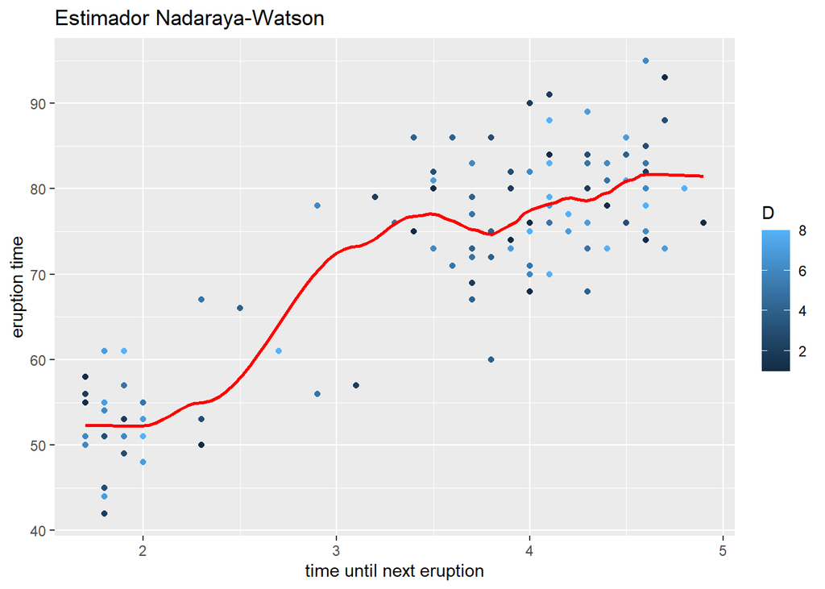

```r
library(ggplot2)

graf1 <- ggplot(datos.geyser,aes(x = X, y = Y,col=D)) +
  geom_point()+
  geom_smooth(method = 'loess', se = FALSE, span = 0.25,
              method.args = list(degree=0), col = 'red')+
  labs(x="time until next eruption",y="eruption time",
       title="Estimador Nadaraya-Watson")
graf1
```

**(b) Representa gráficamente los datos, junto con el estimador localmente lineal de la función de regresión de Y sobre X.**

Empleamos el mismo comando que en el apartado anterior únicamente modificando el grado del polinomio empleado a 1, ya que nos interesa el estimador localmente lineal.

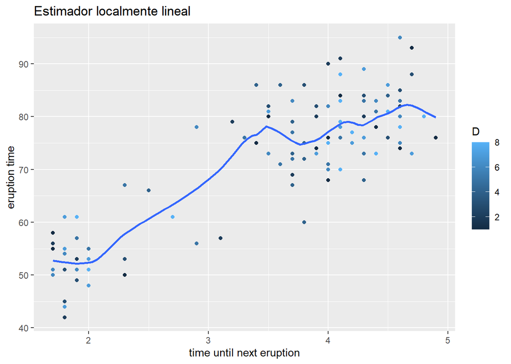

```r
graf2 <- ggplot(datos.geyser,aes(x = X, y = Y, col=D)) +
  geom_point()+
  geom_smooth(method = 'loess', se = FALSE, span = 0.25,
              method.args = list(degree=1))+
  labs(x="time until next eruption", y="eruption time",
       title="Estimador localmente lineal")
graf2
```

Adicionalmente, mostramos las funciones de regresión de ambos estimadores de manera conjunta a modo de comparación. Usamos `ggarrange`, necesitando instalar el paquete `ggpubr`.

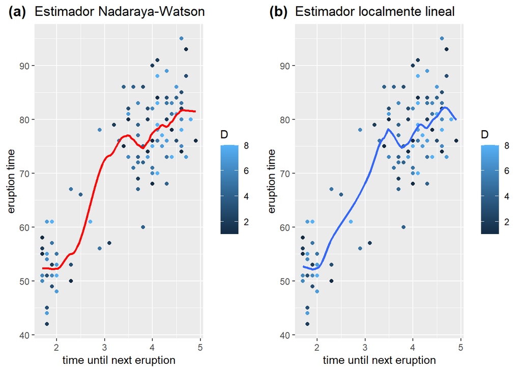

```r
library('ggpubr')
ggarrange(graf1, graf2,labels = c("(a)", "(b)"),ncol = 2, nrow = 1)
```

## Ejercicio 4

**Se considera el siguiente modelo de regresión lineal múltiple:**
$$Y_i = β_0 + β_1x_{i1} + β_2x_{i2} + β_3x_{i3} + \epsilon_i,\hspace{0.4cm} \epsilon_i ≡ N(0, σ^2
),\hspace{0.4cm} i = 1, . . . , n.$$
**Se dispone de n = 20 observaciones con las que se ajustan todos los posibles submodelos del modelo, obteniéndose para cada uno de ellos las siguientes sumas de cuadrados de los residuos (todos los submodelos incluyen un término independiente).**

| Variables incluidas en el modelo | SCR | Variables incluidas en el modelo | SCR |
| --- | --- | --- | --- |
| Sólo término independiente | 42644.00 | $x_1$ y $x_2$ | 7713.13 |
| $x_1$ | 8352.28 | $x_1$ y $x_3$ | 762.55 |
| $x_2$ | 36253.69 | $x_2$ y $x_3$ | **32700.17** |
| $x_3$ | 36606.19 | $x_1$,$x_2$ y $x_3$ | 761.41 |

**(Ejemplo en negrita: Para el modelo ajustado $\hat{Y}_i = \hat{β}_0 + \hat{β}_2x_{i2} + \hat{β}_3x_{i3}$, la suma de cuadrados de los residuos es 32700.17).**

**(a) Calcula la tabla de análisis de la varianza para el modelo y contrasta a nivel $α = 0.05$ la hipótesis nula $H_0 : β_1 = β_2 = β_3 = 0$**

Presentamos en primer lugar la tabla del análisis de la varianza:

[output not shown]

Veámos la construcción de la tabla fila por fila. Para ello tenemos en cuenta los siguientes aspectos:
$$SumSq= SCR_{red}-SCR_{comp} \hspace{0.5cm} y \hspace{0.5cm} MeanSq=\frac{SumSq}{Df}$$
Donde $red$ hace referencia al modelo reducido y $comp$ al completo.

$$F_{k;n-p-1}=\frac{(SCR_0-SCR)/k}{SCR/(n-p-1)}$$

Fila 1

Se comparan los siguientes modelos:

- modelo reducido: $Y_i= β_0 + \epsilon_i$
- modelo completo: $Y_i= β_0 + β_1x_{i1}+ \epsilon_i$

Al añadir una única variable tenemos por tanto que los grados de libertad (Df) son 1.

$$SumSq = SCR_0-SCR_1=42644-8352.28 = 34291.72 = MeanSq$$
Para hallar el estadístico F y el p-valor lo hemos realizado a través de R.

```r
F1=(34291.72/1)/(761.41/16)
print(paste("Estadístico F:",F1))
```

```
## [1] "Estadístico F: 720.594055764962"
```

```r
#toma por defecto alpha=0.05
pv1=pf(F1,1,16,lower.tail = FALSE)
print(paste("p-valor:",pv1))
```

```
## [1] "p-valor: 9.82804845553235e-15"
```

Fila 2

Se comparan los siguientes modelos:

- modelo reducido: $Y_i= β_0 + β_1x_{i1}+ \epsilon_i$
- modelo completo: $Y_i= β_0 + β_1x_{i1}+ β_2x_{i2}+ \epsilon_i$

Por la misma razón tenemos un grado de libertad.

$$SumSq = SCR_1-SCR_{1,2}=8352.28-7713.13 = 639.15 = MeanSq$$

```r
F2=(639.15/1)/(761.41/16)
print(paste("Estadístico F:",F2))
```

```
## [1] "Estadístico F: 13.4308716722922"
```

```r
pv2=pf(F2,1,16,lower.tail = FALSE)
print(paste("p-valor:",pv2))
```

```
## [1] "p-valor: 0.00209220632444154"
```

Fila 3

Se comparan los siguientes modelos:

- modelo reducido: $Y_i= β_0 + β_1x_{i1}+ β_2x_{i2}+ \epsilon_i$
- modelo completo: $Y_i= β_0 + β_1x_{i1}+ β_2x_{i2}+ β_3x_{i3}+ \epsilon_i$

$$SumSq = SCR_{1,2}-SCR_{1,2,3}=7713.13-761.41 = 6951.72 = MeanSq$$

```r
F3=(6951.72/1)/(761.41/16)
print(paste("Estadístico F:",F3))
```

```
## [1] "Estadístico F: 146.080981337256"
```

```r
pv3=pf(F3,1,16,lower.tail = FALSE)
print(paste("p-valor:",pv3))
```

```
## [1] "p-valor: 1.85422793739547e-09"
```

Fila 4

En segundo lugar, contrastaremos a nivel $α = 0,05$ la hipótesis nula $H_0 : β_1 = β_2 = β_3 = 0.$ Para ello empleamos la expresión de $F$ presentada al inicio del apartado y calculamos su correspondiente p-valor.

$$F=\frac{(SCR_0-SCR)/k}{SCR/(n-p-1)}=\frac{(42644-761.41)/3}{761.41/16} =293.3686$$
Donde $k=3$ por haber suprimido 3 variables. Computando el p-valor:

```r
F=((42644-761.41)/3)/(761.41/16)
pf(F,3,16,lower.tail = FALSE)
```

```
## [1] 3.421043e-14
```

Obtenemos un valor muy pequeño, esto se debe a que el estadístico F es muy grande lo que nos indica que la aparición de las 3 variables resulta muy significativa. Consecuentemente debemos rechazar $H_0$.

**(b) En el modelo, contrasta a nivel $α = 0,05$ las dos hipótesis nulas siguientes:**

- $H0 : β2 = 0$
- $H0 : β1 = β3 = 0$

Procedemos de forma análoga al apartado anterior.

Para la primera de ellas tenemos:
$$F=\frac{(SCR_0-SCR)/k}{SCR/(n-p-1)}=\frac{(762.55-761.41)/1}{761.41/16}=0.024$$
Esta vez $k=1$ porque solo igualamos a cero una de las variables del modelo original. En cuanto al p-valor:

```r
Fb1=((762.55-761.41)/1)/(761.41/16)
pf(Fb1,1,16,lower.tail = FALSE)
```

```
## [1] 0.8789337
```

Esta vez el p-valor es considerablemente grande, por lo que no solo no rechazamos $H_0$, sino que lo aceptamos. Esto se debe a que el estadístico F es muy pequeño como podemos observar, esto es, la variable $x_2$ resulta poco significativa para el modelo.

Realizamos el mismo análisis con la segunda hipótesis nula:

```r
Fb2=((36253.69-761.41)/2)/(761.41/16)
pf(Fb2,2,16,lower.tail = FALSE)
```

```
## [1] 3.785566e-14
```

Como ocurría en el apartado (a) el p-valor es muy pequeño y debemos rechazar $H_0$. Concluimos así que las variables $x_1$ y $x_3$ resultan significativas de forma conjunta.

## Ejercicio 6

**Sean $Y_1$, $Y_2$ e $Y_3$ tres variables aleatorias independientes con distribución normal y varianza $σ^2$. Supongamos que $µ$ es la media de $Y_1$, $\lambda$ es la media de $Y_2$ y $\lambda + \mu$ es la media de $Y_3$, donde $\lambda, \mu \in \mathbb{R}$.**

**(a) Demuestra que el vector $Y = (Y_1, Y_2, Y_3)'$ verifica el modelo de regresión múltiple $Y = Xβ + \epsilon$. Para ello, determina la matriz de diseño $X$, el vector de parámetros $β$ y la distribución de las variables de error $\epsilon$.**

Tenemos que:

$$\begin{array}{c}
Y_1=\mu+\epsilon_1\\
Y_2=\lambda+\epsilon_2\\
Y_3=\mu + \lambda+\epsilon_3
\end{array}$$

.

Si ahora lo escribimos de forma matricial:

$$\begin{equation*}
Y=
\begin{pmatrix}
Y_1\\
Y_2\\
Y_3
\end{pmatrix}=
\overbrace{
\begin{pmatrix}
1 & 0\\
0 & 1 \\
1 & 1
\end{pmatrix}}^{X}
\overbrace{\begin{pmatrix}
\mu \\
\lambda
\end{pmatrix}}^{\beta}+
\overbrace{\begin{pmatrix}
\epsilon_1\\
\epsilon_2\\
\epsilon_3
\end{pmatrix}}^{\epsilon}
\end{equation*}$$

Así queda demostrado que el vector $Y$ verifica el modelo de regresión múltiple $Y = Xβ + \epsilon$.

**(b) Calcula los estimadores de máxima verosimilitud (equivalentemente, de mínimos cuadrados) de $\lambda$ y $\mu$.**

Ya vimos en clase que la expresión de los estimadores de mínimos cuadrados es $\hat{β}=(X′X)^{-1}X′Y$. De modo que comenzamos calculando $X'X$ y su inversa.

$$\begin{equation*}
X'X=
\begin{pmatrix}
1 & 0 & 1 \\
0 & 1 & 1
\end{pmatrix}
\begin{pmatrix}
1 & 0 \\
0 & 1 \\
1 & 1 \\
\end{pmatrix}=
\begin{pmatrix}
2 & 1 \\
1 & 2
\end{pmatrix}
\end{equation*}$$

La invertimos en base al método de Gauss Jordan.
$$\begin{equation*}
\begin{pmatrix}
2 & 1 & | 1 & 0 \\
1 & 2 & | 0 & 1
\end{pmatrix} \sim
\begin{pmatrix}
2 & 1 & | & 1 & 0 \\
0 & 3/2 & | -1/2 & 1
\end{pmatrix}\sim
\begin{pmatrix}
2 & 1 & | & 1 & 0 \\
0 & 1 & | & -1/3 & 2/3
\end{pmatrix}\sim
\begin{pmatrix}
2 & 0 & | & 4/3 & -2/3 \\
0 & 1 & | & -1/3 & 2/3
\end{pmatrix} \sim
\begin{pmatrix}
1 & 0 & | & 2/3 & -1/3 \\
0 & 1 & | & -1/3 & 2/3
\end{pmatrix}
\end{equation*}$$

Así $(X'X)^{-1}= \begin{pmatrix} 2/3 & -1/3 \\ -1/3 & 2/3 \end{pmatrix}$. Ya estamos en condiciones de calcular $\hat{\beta}$:

$$\begin{equation*}
\hat{\beta}=(X'X)^{-1}X'Y=
\begin{pmatrix}
2/3 & -1/3 \\
-1/3 & 2/3
\end{pmatrix}
\begin{pmatrix}
1 & 0 & 1 \\
0 & 1 & 1
\end{pmatrix}
\begin{pmatrix}
Y_1\\
Y_2\\
Y_3
\end{pmatrix}= \frac{1}{3}
\begin{pmatrix}
2 & -1 & 1 \\
-1 & 2 & 1
\end{pmatrix}
\begin{pmatrix}
Y_1\\
Y_2\\
Y_3
\end{pmatrix}
\end{equation*}$$

Es decir, los estimadores de máxima verosimilitud de $\mu$ y $\lambda$ son:
$$\begin{array}{c}
\hat{\mu}=\frac{1}{3}(2Y_1-Y_2+Y_3)\\
\hat{\lambda}=\frac{1}{3}(-Y_1+2Y_2+Y_3)
\end{array}$$

.

**(c) Calcula la distribución del vector $(\hat{\lambda}, \hat{\mu})$, formado por los estimadores calculados en el apartado anterior.**

También vimos en clase que el vector $\hat{β}$ tiene distribución normal (p+1)-dimensional con vector de medias $β$ y matriz de covarianzas $σ^2(X′X)^{−1}$, es decir, $\hat{β}\equiv\mathcal{N}_{p+1}(β,σ^2(X′X)^{-1})$. Por tanto en este caso particular tenemos:
$$\hat{\beta}=\begin{pmatrix} \hat{\mu} \\ \hat{\lambda} \end{pmatrix}\equiv\mathcal{N}_2\left( \begin{pmatrix} \mu \\ \lambda \end{pmatrix} , \sigma^2 \begin{pmatrix} 2/3 & -1/3 \\ -1/3 & 2/3 \end{pmatrix} \right)$$
Y por las propiedades de la distribución normal multivariante

$$\begin{array}{c}
\hat{\mu}\equiv \mathcal{N}(\mu, \frac{2}{3}\sigma^2)\\
\hat{\lambda}\equiv \mathcal{N}(\lambda, \frac{2}{3}\sigma^2)
\end{array}$$

.

## Ejercicio 10

**Los datos *fuel2001* del fichero combustible.RData (véase transparencias de clase) corresponden al consumo de combustible (y otras variables relacionadas) en los estados de EE.UU. Se desea explicar la variable *FuelC* en función del resto de la información.**

**(a) Representa en un plano las dos primeras componentes principales de estos datos estandarizados (consulta la ayuda de *prcomp*). ¿Son suficientes estas dos componentes para explicar un alto porcentaje de la varianza?**

En primer lugar cargamos los datos

```r
load("C:/Users/usuario/Desktop/MAE/Entrega3/combustible.RData")
```

Para la representación hacemos uso de `prcomp` que realiza un análisis de componentes principales en la matriz de datos de entrada. Además con `scale.=T` las variables se escalan para tener varianza unitaria. Posteriormente tomamos las dos primeras componentes y las graficamos.

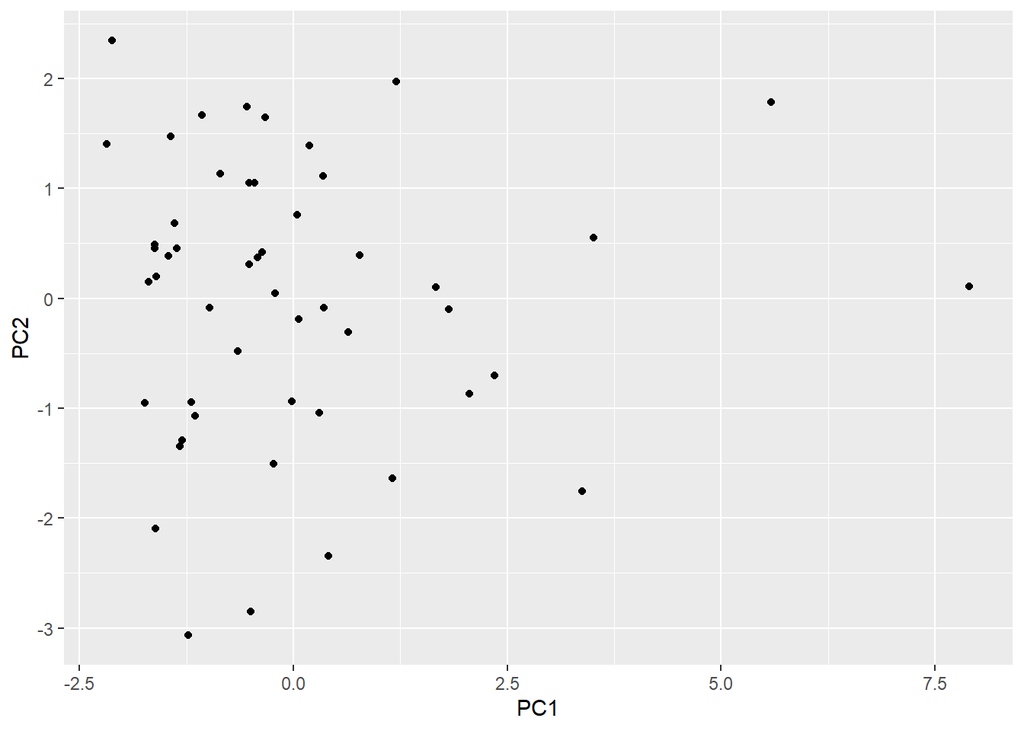

```r
prcomp_fuel <- prcomp(fuel2001, scale.=T)
pca_fuel <- data.frame(PC1 = prcomp_fuel$x[, 1],PC2 = prcomp_fuel$x[, 2])

ggplot(pca_fuel, aes(x = PC1, y = PC2)) +
  geom_point()
```

Con el objetivo de saber que porcentaje de varianza explicamos con estas dos primeras componentes calculamos la varianza acumulada. Hemos tenido en cuenta que la variable `sdev` de `prcomp_fuel` es la desviación estándar de las componentes principales, o lo que es lo mismo, las raíces cuadradas de los valores propios.

```r
var_acumulada <- cumsum(prcomp_fuel$sdev^2) / sum(prcomp_fuel$sdev^2)
print(paste("Varianza explicada con la primera componente:",var_acumulada[1]))
```

```
## [1] "Varianza explicada con la primera componente: 0.525617382471717"
```

```r
print(paste("Varianza explicada con la segunda componente:",var_acumulada[2]-var_acumulada[1]))
```

```
## [1] "Varianza explicada con la segunda componente: 0.229103196981591"
```

```r
print(paste("Varianza explicada con la primera y segunda componente:",var_acumulada[2]))
```

```
## [1] "Varianza explicada con la primera y segunda componente: 0.754720579453308"
```

También lo analizamos gráficamente, para el primero de los plots hemos cargado el paquete `factoextra`.

```r
library(factoextra)
```

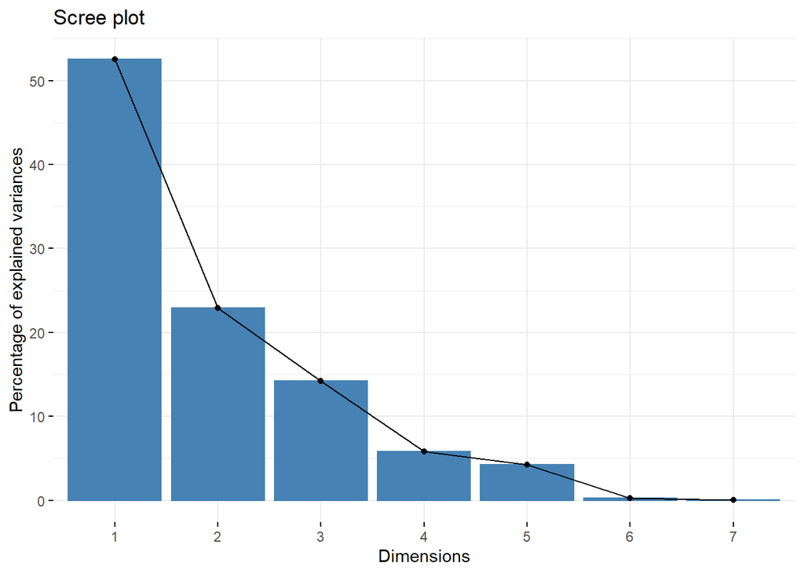

```r
#plot1
fviz_eig(prcomp_fuel)
```

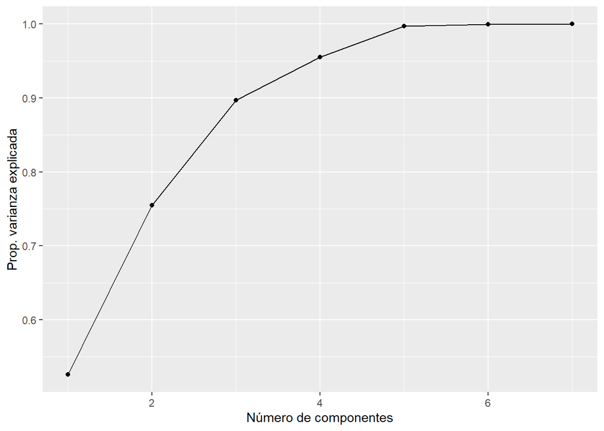

```r
#plot2
sdev <- data.frame(indice = 1:7, var_acumulada)
ggplot(sdev, aes(x = indice, y = var_acumulada)) +
  geom_line() +
  geom_point() +
  labs(x = "Número de componentes", y = "Prop. varianza explicada")
```

Vemos que con las dos primeras componentes principales se explica alrededor del 75% de la varianza. Aunque este no es un valor pequeño, quizá resulte insuficiente para determinados estudios. Además vemos en el primero de los gráficos generados como la tercera componente tiene una considerbale influencia en el porcentaje de varianza explicada, entorno al 15%, por lo que considerando esta ya obtendríamos alrededor del 90% de explicación. Esto se observa en la segunda de las imágenes. En resumen, para un estudio más riguroso seguramente optaríamos por tomar 3 componentes principales.

**(b)Ajusta el modelo completo con todas las variables. En este modelo completo, contrasta la hipótesis nula de que los coeficientes de las variables *Income*, *MPC* y *Tax* son simultáneamente iguales a cero.**

Ajustamos el modelo completo y el reducido, posteriormente los contrastamos (tabla de análisis de la varianza).

```r
Drivers<-fuel2001$Drivers
FuelC<-fuel2001$FuelC
Income<-fuel2001$Income
Miles<-fuel2001$Miles
MPC<-fuel2001$MPC
Pop<-fuel2001$Pop
Tax<-fuel2001$Tax

#Ajuste modelo completo
modelo_completo <- lm(FuelC~., data=fuel2001)

#H0: Income(x3)=MPC(x5)=Tax(x7)=0
modelo_red <- lm(FuelC~Drivers+Miles+Pop, data=fuel2001)

#contraste
anova(modelo_red,modelo_completo)
```

```
## Analysis of Variance Table
##
## Model 1: FuelC ~ Drivers + Miles + Pop
## Model 2: FuelC ~ Drivers + Income + Miles + MPC + Pop + Tax
##   Res.Df        RSS Df  Sum of Sq      F Pr(>F)
## 1     47 7.8556e+12
## 2     44 6.9843e+12  3 8.7128e+11 1.8296 0.1557
```

El p-valor obtenido es de 0.1557, este no es suficientemente pequeño como para rechazar la hipótesis nula si tomamos un $\alpha=0.05$. De todas formas tampoco resulta suficientemente grande como para aceptar $H_0$ y considerar que las variables *Income*, *MPC* y *Tax* no son significativas de forma conjunta.

**(c) De acuerdo con el método iterativo hacia adelante y el criterio BIC, ¿cuál es el modelo óptimo?**

En primer lugar empleamos el método iterativo hacia delante (forward) para obtener las variables más significativas. Posteriormente se estudia mediante el criterio BIC el modelo óptimo.

```r
# método iterativo hacia adelante
modelo_forward <- leaps::regsubsets(FuelC ~ ., data=fuel2001 ,method='forward')
resumen_forward <- summary(modelo_forward)
resumen_forward
```

```
## Subset selection object
## Call: regsubsets.formula(FuelC ~ ., data = fuel2001, method = "forward")
## 6 Variables  (and intercept)
##         Forced in Forced out
## Drivers     FALSE      FALSE
## Income      FALSE      FALSE
## Miles       FALSE      FALSE
## MPC         FALSE      FALSE
## Pop         FALSE      FALSE
## Tax         FALSE      FALSE
## 1 subsets of each size up to 6
## Selection Algorithm: forward
##          Drivers Income Miles MPC Pop Tax
## 1  ( 1 ) "*"     " "    " "   " " " " " "
## 2  ( 1 ) "*"     " "    "*"   " " " " " "
## 3  ( 1 ) "*"     " "    "*"   " " " " "*"
## 4  ( 1 ) "*"     " "    "*"   "*" " " "*"
## 5  ( 1 ) "*"     "*"    "*"   "*" " " "*"
## 6  ( 1 ) "*"     "*"    "*"   "*" "*" "*"
```

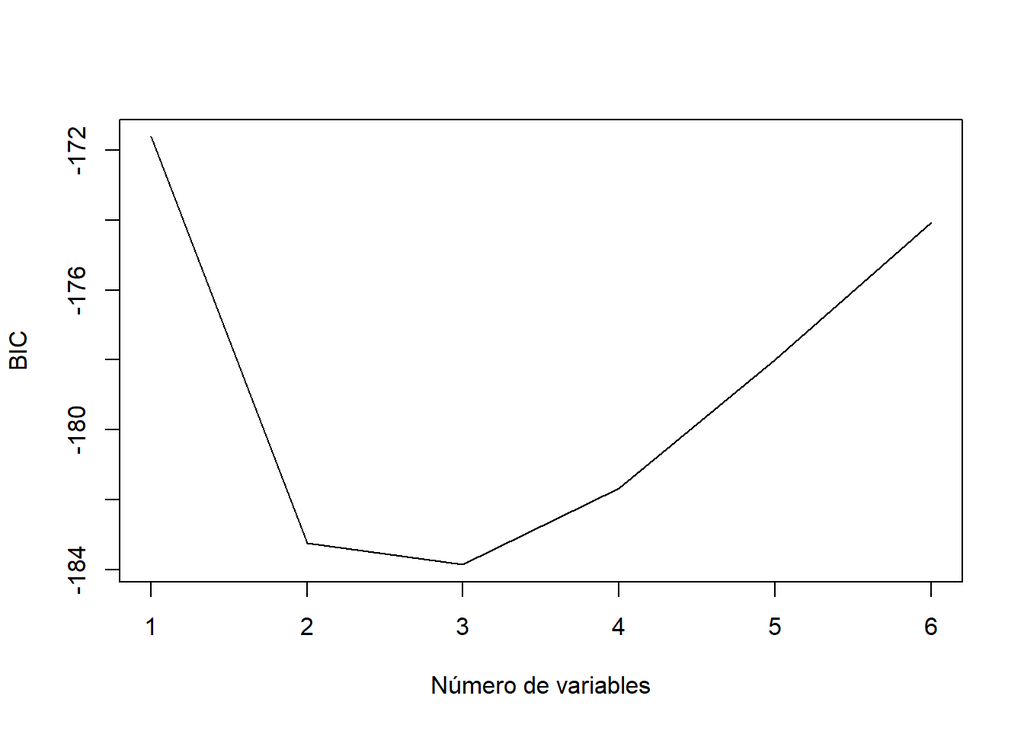

```r
#BIC
plot(resumen_forward$bic ,xlab =" Número de variables ",
     ylab="BIC",type="l")
```

El gráfico indica que el modelo óptimo es aquel que toma 3 variables, siendo este:
$$FuelC=\beta_0+\beta_1Drivers+\beta_2Miles+\beta_3Tax$$

**(d) Ajusta el modelo usando lasso, con el parámetro de regularización seleccionado mediante validación cruzada.**

Parausar *lasso* empleamos el paquete `glmnet` e instalamos su correspondiente librería, debemos fijar el parámetro $alpha=1$. Posteriormente seleccionamos el parámetro de regularización (lambda) mediante validación cruzada así ajustando el modelo.

```r
library(glmnet)
```

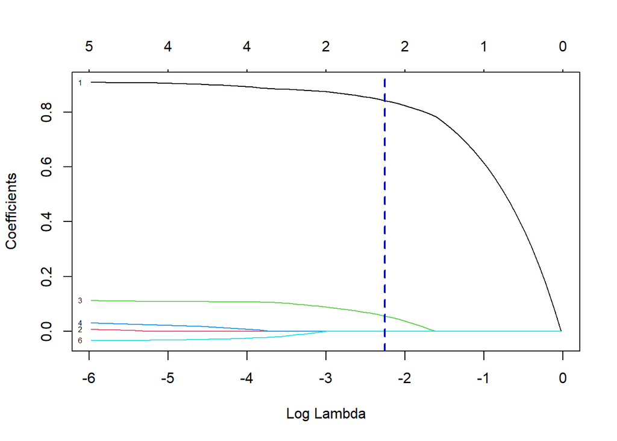

```r
#escalamos los datos
data<-data.frame(scale(fuel2001))
#guardamos una matriz con todas las columnas menos FuelC (col 2)
x <- as.matrix(data[,-2])
y <- data[,2] #FuelC

#lasso
modelo_lasso <- glmnet(x, y, alpha = 1)
plot(modelo_lasso, xvar='lambda', label=TRUE)

#parámetro de regularización(lambda) mediante validación cruzada
lasso_cv <- cv.glmnet (x , y, alpha = 1)
lambda.lasso <- lasso_cv$lambda.1se
abline(v = log(lambda.lasso), lty=2, col='blue', lwd=2)
```

Vemos como el ajuste mediante lasso conincide con el realizado por el método BIC en el orden en el que se eligen las variables a medida que el modelo aumenta. Sin embargo para lasso se obtiene que el modelo óptimo toma únicamente las variables *Drivers* y *Miles*, esto es
$$FuelC=\beta_0+\beta_1Drivers+\beta_2Miles$$

Calculamos también los coeficientes

```r
modelo_final_lasso <- glmnet(x, y, alpha = 1, lambda = lambda.lasso)
coef(modelo_final_lasso)
```

```
## 7 x 1 sparse Matrix of class "dgCMatrix"
##                       s0
## (Intercept) 5.283776e-17
## Drivers     8.424964e-01
## Income      .
## Miles       5.531908e-02
## MPC         .
## Pop         .
## Tax         .
```

**(e) Ajusta el modelo usando ridge, con el parámetro de regularización seleccionado mediante validación cruzada.**

Para *ridge* actúamos de forma análoga pero esta vez debemos de fijar el parámetro $alpha=0$.

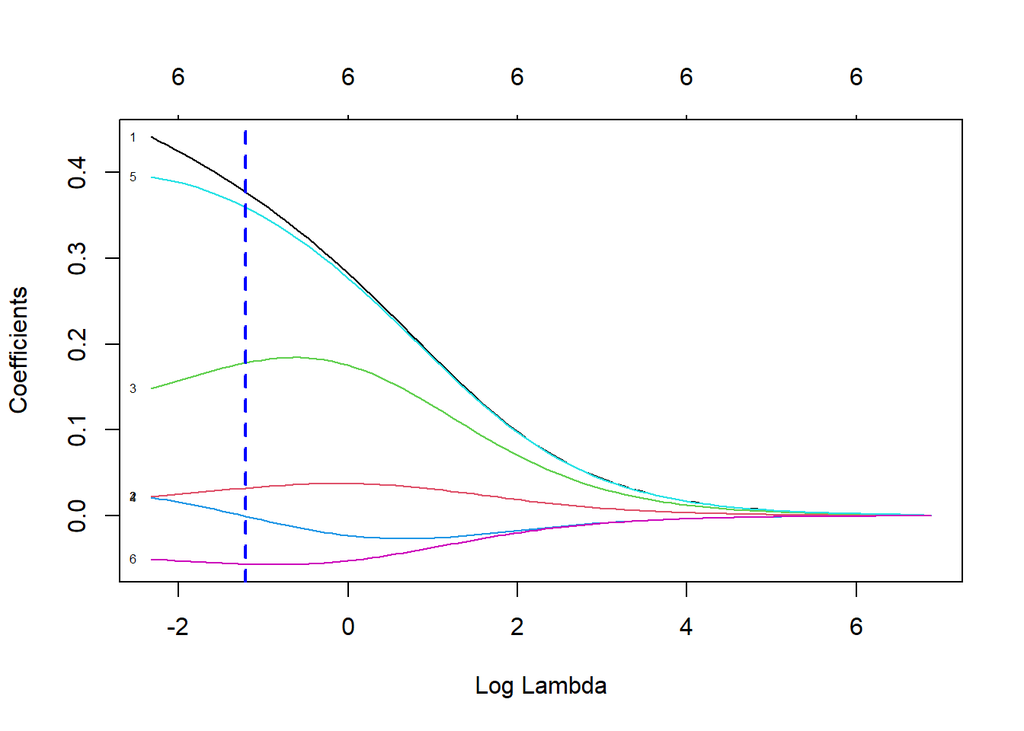

```r
modelo_ridge <- glmnet(x, y, alpha = 0)
plot(modelo_ridge, xvar='lambda', label=TRUE)

#parámetro de regularización(lambda) mediante validación cruzada
ridge_cv <- cv.glmnet (x , y, alpha = 0)
lambda.ridge <- ridge_cv$lambda.1se
abline(v = log(lambda.ridge), lty=2, col='blue', lwd=2)
```

Con este método se consideran todas y cada una de las variables para el modelo óptimo, lo que nos conduce a pensar que funciona peor. Así el modelo sería
$$FuelC=\beta_0+\beta_1Drivers+\beta_2Income+\beta_3Miles+\beta_4MPC+\beta_5Pop+\beta_6Tax$$

En concreto se toman los coeficientes siguientes

```r
modelo_final_ridge <- glmnet(x, y, alpha = 0, lambda = lambda.ridge)
coef(modelo_final_ridge)
```

```
## 7 x 1 sparse Matrix of class "dgCMatrix"
##                        s0
## (Intercept)  2.553365e-17
## Drivers      3.772311e-01
## Income       3.229044e-02
## Miles        1.780619e-01
## MPC         -4.974436e-04
## Pop          3.593909e-01
## Tax         -5.637201e-02
```